# Technology and Social Change

Lecture 13: AI, State Surveillance and Human Rights

Bogdan G. Popescu

bgpopescu@tec.mx

Tecnológico de Monterrey

# Part 1: The Central Question

## The Central Question

**When does AI strengthen democracy — and when does it undermine it?**

The same technologies are deployed in Beijing, Berlin, and Brasília — with very different consequences for citizens.

*The answer, this lecture argues, lies in institutions.*

“**Institutions**” - mechanisms that determine whether state power can be challenged: courts, elections, free media, civil society, etc

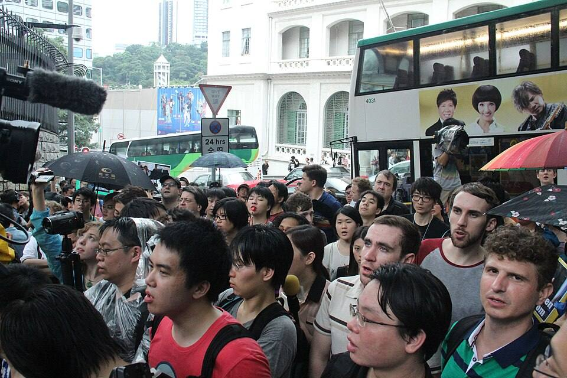

Pro-privacy protesters rally in Hong Kong in support of Edward Snowden, 2013. Source: VOA / Wikimedia Commons (public domain).

## Learning Objectives

By the end of this lecture, you should be able to:

1. **Explain how AI lowers the cost of monitoring** and what this means for state capacity
2. **Apply the privacy-as-power framework** to analyze citizen–institution asymmetries
3. **Recognize the distributional consequences** of AI surveillance for marginalized groups
4. **Predict variation in AI’s democratic effects** across regime types and identify the institutions that determine the outcome

## The Master Causal Framework

```
%%{init: {'theme':'base','themeVariables':{'fontSize':'20px','primaryColor':'#e8eeeb','primaryTextColor':'#1e293b','primaryBorderColor':'#4a7c6f','lineColor':'#334155','secondaryColor':'#f5f0e8','tertiaryColor':'#fdf2e9'},'flowchart':{'useMaxWidth':true,'width':1150,'height':650,'nodeSpacing':40,'ra…
flowchart LR
  A["AI<br/>Capability"] --> B["Data<br/>Extraction"]
  B --> C["Surveillance &<br/>Decision Systems"]
  C --> D["Power Shift:<br/>State vs. Citizens"]
  D --> I{"Institutions<br/>(strong or weak?)"}
  I -->|strong checks| R["Re-equilibration:<br/>reform &<br/>accountability"]
  I -->|weak checks| X["De-democratization:<br/>repression &<br/>exclusion"]
```

*Author’s illustration. Institutions are the moderator: the same AI capability produces opposite outcomes depending on the strength of judicial, media, civic, and regulatory checks.*

## Four Anchor Scholars

**James Scott** — *Seeing Like a State* (1998)  
States simplify society to make it “legible” for control

**Charles Tilly** — *Coercion, Capital, and European States* (1990)  
State capacity = extraction + monitoring + coercion

**Acemoglu & Robinson** — *Why Nations Fail* (2012)  
Inclusive vs. extractive institutions determine accountability

**Julie Cohen** — *Between Truth and Power* (2019)  
Privacy is a *power resource*, not mere secrecy

# Part 2: The Mechanism — AI Lowers the Cost of State Surveillance

## AI as Task Automation

**Prediction**: Given inputs, forecast likely outcomes

- Credit default, recidivism, disease outbreaks

**Classification**: Given inputs, assign categories

- Face to identity; text to sentiment; behavior to threat

**Generation**: Given prompts, produce content

- Text, images, synthetic media for disinformation

## AI Reduces State Monitoring Costs

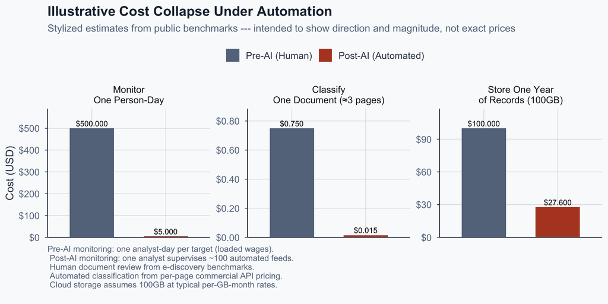

Figure 1

## Key Technical Capabilities for State Control

*Each AI capability serves a distinct state goal — making populations legible, predictable, or governable.*

**Facial Recognition** — Match faces across databases; identify in crowds → *Goal: Identify who is where, in real time*

**Natural Language Processing** — Analyze text at scale; detect sentiment → *Goal: Detect dissent and shape public discourse*

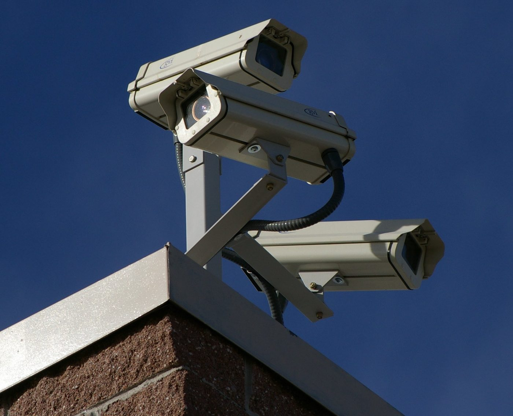

CCTV cameras: the visible infrastructure of state monitoring. AI transforms passive recording into active, real-time identification and tracking. Source: Wikimedia Commons.

## Key Technical Capabilities for State Control

*Each AI capability serves a distinct state goal — making populations legible, predictable, or governable.*

**Predictive Analytics** — Risk-score individuals; forecast protests → *Goal: Pre-empt threats before they materialize*

**Behavioral Biometrics** — Identify by gait, typing, voice patterns → *Goal: Track individuals even when faces are hidden*

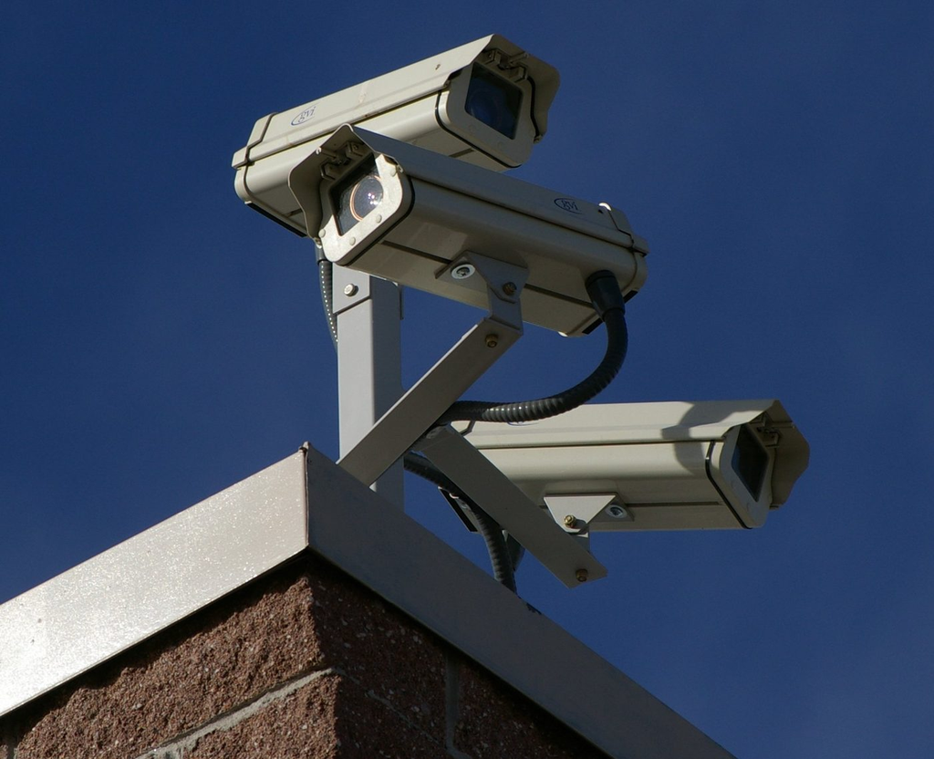

CCTV cameras: the visible infrastructure of state monitoring. AI transforms passive recording into active, real-time identification and tracking. Source: Wikimedia Commons.

## Tilly’s State Capacity Framework

Charles Tilly identified four core state-making activities:

- **War making** — eliminating rivals outside the territory
- **State making** — eliminating rivals inside the territory
- **Protection** — eliminating rivals of the state’s clients
- **Extraction** — acquiring the resources to do the other three

*AI enhances all four, but especially **extraction** (data as a new resource) and **state making** (internal control via legibility — Scott’s bridge to Tilly).*

## How States Use AI to Control Populations

| Instrument | State Incentive | Rights Risk | Failure Mode |
| --- | --- | --- | --- |
| Mass Surveillance | Threat detection | Privacy, assembly | Function creep |
| Predictive Policing | Efficiency | Due process | Feedback loops |
| Welfare Fraud Detection | Cost reduction | Dignity | False positives |
| Social Credit Systems | Compliance | Autonomy | Arbitrariness |
| Border Control | Security | Asylum rights | Exclusion errors |
| Censorship | Narrative control | Expression | Overblocking |

*Author’s illustration based on comparative policy analysis.*

## Scott’s Legibility Concept

**Core claim**: States simplify complex social reality to govern

- Standardized names, maps, censuses, registries

**Legibility enables intervention**:

- What can be *seen* can be measured and targeted

**AI vastly expands legibility**:

- Movement, social networks, emotions now trackable
- AI is “Seeing Like a State 2.0”

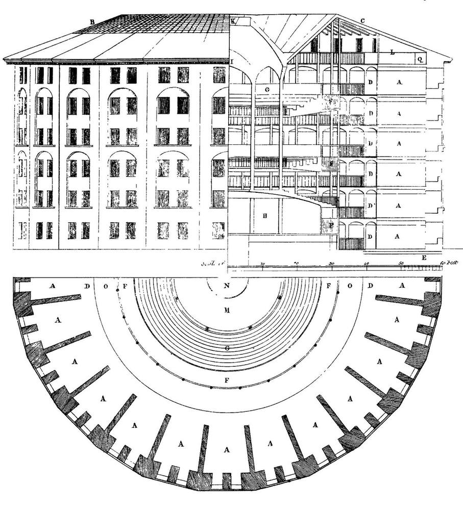

Jeremy Bentham’s Panopticon (1791): a prison designed so inmates could be watched at any time without knowing when. AI-enabled surveillance generalizes this principle to entire populations. Source: Wikimedia Commons (public domain).

## Surveillance Produces Chilling Effects

```
%%{init: {'theme':'base','themeVariables':{'fontSize':'22px','primaryColor':'#e8eeeb','primaryTextColor':'#1e293b','primaryBorderColor':'#4a7c6f','lineColor':'#334155','secondaryColor':'#f5f0e8','tertiaryColor':'#fdf2e9'},'flowchart':{'useMaxWidth':true,'width':1150,'height':650,'nodeSpacing':50,'ra…
flowchart LR
  A["AI-Enabled<br/>Surveillance"] --> B["Belief One<br/>Is Watched"]
  B --> C["Self-<br/>Censorship"]
  C --> D["Reduced Dissent<br/>& Participation"]
  D --> E["Democratic<br/>Erosion"]
```

*Author’s illustration. Even without punishment, belief in surveillance changes behavior — especially dissent (Penney, 2016).*

## Case: Predictive Policing

**How it works**:

- Historical crime + demographic data produce risk scores
- Police resources allocated to “high-risk” areas

**The feedback loop**:

- More policing leads to more detected crime leads to higher scores

## Case: Predictive Policing

**What is actually being predicted?**

- The model is trained on **arrest data**, not crime data
- Arrests reflect *where police already go* — not where crime actually occurs
- **Predictive policing predicts where policing has happened, not where crime happens** (Lum & Isaac, 2016)

**Distributional consequence**:

- Over-policed communities remain over-policed
- The model can look “accurate” while reproducing historical discrimination

## The Predictive Policing Feedback Loop

```
%%{init: {'theme':'base','themeVariables':{'fontSize':'22px','primaryColor':'#e8eeeb','primaryTextColor':'#1e293b','primaryBorderColor':'#4a7c6f','lineColor':'#334155','secondaryColor':'#f5f0e8','tertiaryColor':'#fdf2e9'},'flowchart':{'useMaxWidth':true,'width':1150,'height':650,'nodeSpacing':50,'ra…
flowchart LR
  A["Historical<br/>Crime Data"] --> B["ML Model<br/>Trains"]
  B --> C["Predicts Risk<br/>in Same Areas"]
  C --> D["Police Deployed<br/>to Those Areas"]
  D --> E["More Arrests<br/>Recorded There"]
  E --> A
```

*Author’s illustration. The prediction changes the outcome it predicts (“performative prediction”).*

## Selective Enforcement and Legitimacy

**The selective enforcement logic**:

- AI provides comprehensive information on violations
- States cannot enforce all laws; discretion is political

**Consequences**:

- Laws become weapons against opponents
- Compliance with law does not guarantee safety

**Acemoglu & Robinson**: Extractive institutions use law instrumentally; inclusive institutions constrain discretion

# Part 3: The Stakes — Privacy, Power, and Distributional Harm

## Privacy as a Power Resource

Privacy is not secrecy (“nothing to hide, nothing to fear”). For Julie Cohen, it is a **power resource** that protects autonomy by limiting the information asymmetry between individuals and institutions.

```
%%{init: {'theme':'base','themeVariables':{'fontSize':'22px','primaryColor':'#e8eeeb','primaryTextColor':'#1e293b','primaryBorderColor':'#4a7c6f','lineColor':'#334155','secondaryColor':'#f5f0e8','tertiaryColor':'#fdf2e9'},'flowchart':{'useMaxWidth':true,'width':1150,'height':650,'nodeSpacing':50,'ra…
flowchart LR
  A["Institution Knows<br/>Much About You"] --> C["Information<br/>Asymmetry"]
  B["You Know Little<br/>About Institution"] --> C
  C --> D["Power<br/>Imbalance"]
  D --> E["Privacy Protection =<br/>Reduce Asymmetry"]
```

*Author’s illustration based on Cohen (2019). The individual is transparent; the institution is opaque.*

## Rights Tradeoffs in AI Governance

**Security vs. Liberty**

- Surveillance may reduce crime — but restricts freedom

**Automation vs. Accountability**

- Automated decisions are fast and consistent — but opaque and hard to contest

## Rights Tradeoffs in AI Governance

**False Positives vs. False Negatives**

- Every threshold trades one error for the other — *who* bears each kind?

*The question is not whether tradeoffs exist, but who decides.*

## Who Bears the Harms?

**Pattern**: AI harms fall disproportionately on marginalized groups (O’Neil, 2016; Eubanks, 2018; Benjamin, 2019)

- Facial recognition: higher error on darker-skinned faces (Buolamwini & Gebru, 2018)
- Predictive policing: over-policing minority neighborhoods (Lum & Isaac, 2016)
- Welfare systems: poorest face most intrusive scrutiny (Eubanks, 2018)

**Why this pattern?**

- Training data reflects historical discrimination (Barocas & Selbst, 2016)
- Affected groups have less power to contest errors (Eubanks, 2018)
- Harms to marginalized groups are politically cheaper (Benjamin, 2019)

[figure not shown]

Facial recognition scanning at an airport gate, 2018. The same technology produces disparate accuracy across demographic groups. Source: Delta News Hub / Wikimedia Commons (CC BY 2.0).

## Facial Recognition Accuracy Disparities

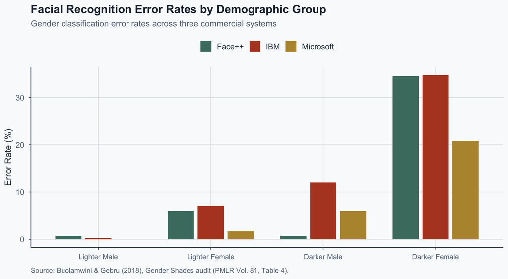

Figure 2

## Case Evidence: Wrongful Arrest by Facial Recognition

[video not shown]

Source: https://www.youtube.com/watch?v=Cx284WjpEQY

1. How much more likely was facial recognition to misidentify Black people than white people — and what causes this disparity?  
2. The Police said FR matches are used “as a clue, not as proof.” Why does this safeguard still fail in Robert Williams’s case?  
3. The startup proposes “synthetic digital humans” to fix bias. Are there limits of that fix?

# Part 4: The Answer — Institutions Decide

## Acemoglu & Robinson: Institutions Matter

**Core distinction**:

- **Inclusive** institutions distribute power and constrain elites
- **Extractive** institutions concentrate power for elite benefit

**Applied to AI surveillance**:

- Inclusive institutions: AI constrained by law and oversight
- Extractive institutions: AI amplifies elite control

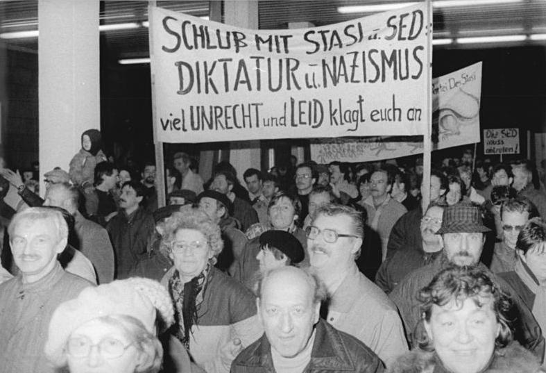

East Germans storm the Stasi headquarters, Berlin, January 1990. The Stasi maintained files on 5.6 million people — a surveillance state dismantled by institutional change. Source: Bundesarchiv / Wikimedia Commons.

## Acemoglu & Robinson: Institutions Matter

**Key insight**: Same technology, different outcomes by institutional context

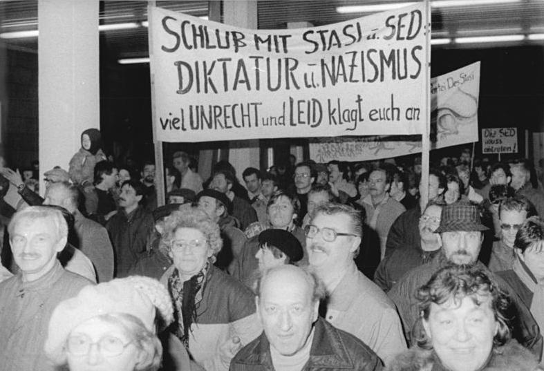

East Germans storm the Stasi headquarters, Berlin, January 1990. The Stasi maintained files on 5.6 million people — a surveillance state dismantled by institutional change. Source: Bundesarchiv / Wikimedia Commons.

## Regime Types and AI Outcomes

```
%%{init: {'theme':'base','themeVariables':{'fontSize':'20px','primaryColor':'#e8eeeb','primaryTextColor':'#1e293b','primaryBorderColor':'#4a7c6f','lineColor':'#334155','secondaryColor':'#f5f0e8','tertiaryColor':'#fdf2e9'},'flowchart':{'useMaxWidth':true,'width':1150,'height':650,'nodeSpacing':35,'ra…
flowchart LR
  A["Same AI<br/>Technology"] --> B["Democracy<br/>(Inclusive)"]
  A --> C["Hybrid<br/>Regime"]
  A --> D["Autocracy<br/>(Extractive)"]
  B --> E["Constrained Use<br/>Courts, Press, Elections"]
  C --> F["Volatile Outcomes<br/>Leader-Dependent"]
  D --> G["Systematic<br/>Repression"]
```

*Author’s illustration based on Acemoglu & Robinson (2012).*

## What Constrains AI State Power?

Whether AI produces reform or repression depends on which institutions are strong enough to check it.

| Safeguard | What It Prevents in AI Surveillance | What It Cannot Prevent |
| --- | --- | --- |
| Judicial independence | Warrantless monitoring; AI evidence used without due-process review | Slow response to fast-moving tech |
| Media freedom | Hidden surveillance contracts; undisclosed algorithmic harms | AI-amplified disinformation |
| Civil society | AI procurement without public debate; black-box deployment | Repression; co-optation |
| Data protection authority | Mass scraping; unlawful training-data collection; function creep | Under-resourcing; regulatory capture |

**No single safeguard is sufficient — protection comes from layered institutions.**

## Why Safeguards Fail in Practice

Even strong institutions break down when politics, expertise, and secrecy work against them.

- **National-security exceptions swallow the rule** — “intelligence” carve-outs exempt the largest systems
- **Courts lack technical expertise** — judges struggle to evaluate algorithmic evidence
- **Vendors invoke trade secrecy** — private firms refuse to disclose how their models work
- **Affected citizens often don’t know** they were scored, flagged, or matched
- **Regulators are under-resourced** — data protection authorities lack the staff to enforce
- **“Human-in-the-loop” becomes rubber-stamping** — officers trust the AI’s output rather than challenging it

## AI and the Foundations of Democracy

**Boix (2022)**: AI threatens democracy through *three* reinforcing channels

**1. Economic**: AI may widen inequality (capital vs. labor), weakening the social consensus that sustains democratic rule

**2. Informational**: AI empowers *both* opposition coordination *and* state repression—but authoritarian regimes have structural advantages in deploying repression

**3. Cost of exclusion**: AI lowers the cost of identifying, monitoring, and preempting opponents—making it cheaper to suppress dissent

## AI and the Foundations of Democracy

**Key insight**: In strong democracies, elections can “re-equilibrate” policy in response to AI shocks. In emerging and peripheral economies, AI is more likely to be **de-democratizing** (Boix, 2022).

Source: Boix (2022), *Oxford Handbook of AI Governance*

## Global Surveillance Camera Density

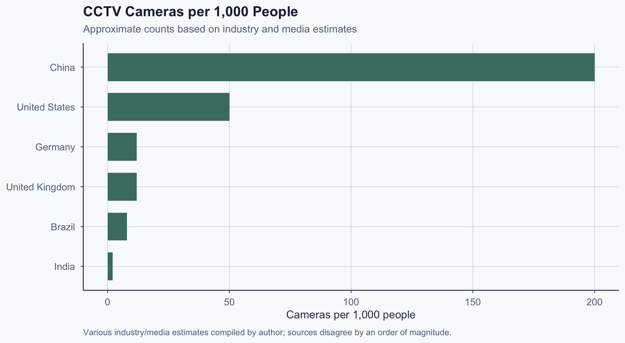

Figure 3

## What Works Where?

| Tool | Democracy | Hybrid Regime | Autocracy |
| --- | --- | --- | --- |
| Data minimization | Effective (enforceable) | Partial (inconsistent) | Ineffective (state ignores) |
| Algorithmic auditing | Effective (capacity exists) | Limited (expertise lacking) | Cosmetic (regime controls) |
| Judicial authorization | Effective (independent courts) | Variable (courts pressured) | Ineffective (courts captured) |
| International pressure | Moderate (less needed) | Potentially effective | Potentially effective (if costs imposed) |

*Author’s illustration. Effectiveness depends on institutional context, not technical design alone.*

## Summary: Four Key Takeaways

**1. AI collapses the cost of monitoring** — mass surveillance and predictive flagging are now cheap and scalable.

**2. Privacy is a power resource** — AI widens the asymmetry between transparent citizens and opaque institutions (Cohen).

**3. Harms fall unequally** — biased data and weak contestability concentrate costs on marginalized groups (Buolamwini & Gebru; Eubanks).

**4. Institutions decide the outcome** — strong democracies re-equilibrate; AI is most de-democratizing where checks are weakest (Boix; Acemoglu & Robinson).

## References

Boix, C. (2022). AI and the economic and informational foundations of democracy. In J. B. Bullock et al. (Eds.), *The Oxford Handbook of AI Governance*. Oxford University Press.

Scott, J. C. (1998). Seeing like a state: How certain schemes to improve the human condition have failed. Yale University Press.

Tilly, C. (1990). Coercion, capital, and European states, AD 990–1990. Basil Blackwell.

Acemoglu, D., & Robinson, J. A. (2012). Why nations fail: The origins of power, prosperity, and poverty. Crown Business.

Cohen, J. E. (2019). *Between truth and power: The legal constructions of informational capitalism*. Oxford University Press.

Cohen, J. E. (2019). Turning privacy inside out. *Theoretical Inquiries in Law*, 20(1), 1–31.

Buolamwini, J., & Gebru, T. (2018). Gender shades: Intersectional accuracy disparities in commercial gender classification. Proceedings of Machine Learning Research, 81, 77–91.

## References

Barocas, S., & Selbst, A. D. (2016). Big data’s disparate impact. *California Law Review*, 104(3), 671–732.

Benjamin, R. (2019). *Race after technology: Abolitionist tools for the new Jim code*. Polity Press.

Eubanks, V. (2018). *Automating inequality: How high-tech tools profile, police, and punish the poor*. St. Martin’s Press.

Lum, K., & Isaac, W. (2016). To predict and serve? *Significance*, 13(5), 14–19.

O’Neil, C. (2016). *Weapons of math destruction: How big data increases inequality and threatens democracy*. Crown.

Penney, J. W. (2016). Chilling effects: Online surveillance and Wikipedia use. Berkeley Technology Law Journal, 31(1), 117–182.

Comparitech. (2021). Surveillance camera statistics: Which cities have the most CCTV cameras?